# Introduction: Jupyter Notebooks & Python

## 1. Hello, World!

To run the code, click anywhere into the cell (the box with the code inside), and then type `Shift` + `Enter` (`Shift` + `Return` on a Mac) to execute.

```python
print("Hello, World!")
```

```
Hello, World!
```

this is my note for the Thursday class

## 2. Very useful shortcuts

There are two types of cells in Jupyter Notebooks: code and markdown. This is a markdown cell. You can write notes in markdown cells using the markdown language.

- `Esc` will take you into command mode where you can navigate around your notebook with arrow keys.
- While in command mode:
  - `A` to insert a new cell above the current cell, `B` to insert a new cell below.
  - `M` to change the current cell to Markdown, `Y` to change it back to code
  - `D` + `D` (press the key twice) to delete the current cell
- `Enter` will take you from command mode back into edit mode for the given cell.

## 3. Running some simple codes with `print` statements

```python
print(f"The temperature 75F in degrees celsius is {(75 - 32) * 5 / 9}C")
```

```
The temperature 75F in degrees celsius is 23.88888888888889C
```

```python
print(f"Isabel is {28/7} dog years old.")
```

```
Isabel is 4.0 dog years old.
```

What if you wanted to display a whole number, which is much more natural when speaking about ages?

```python
print(f"Isabel is {28/7:.0f} dog years old.")
```

```
Isabel is 4 dog years old.
```

The following `multi-line` `f-string` includes a description of how Americans use measurements in units that are not in the metric system. It displays the equivalent milliliters (ml) for 8 fluid ounces of milk and the equivalent fluid ounces to 100 ml of water.

```python
print(f"""
    Most countries use the metric system for recipe measurement,
    but American bakers use a different system. For example, they use
    fluid ounces to measure liquids instead of milliliters (ml).

    So you need to convert recipe units to your local measuring system!

    For example, 8 fluid ounces of milk is {8 * 29.5735} ml.
    And 100ml of water is {100 / 29.5735} fluid ounces.
""")
```

```
    Most countries use the metric system for recipe measurement,
    but American bakers use a different system. For example, they use
    fluid ounces to measure liquids instead of milliliters (ml).

    So you need to convert recipe units to your local measuring system!

    For example, 8 fluid ounces of milk is 236.588 ml.
    And 100ml of water is 3.381405650328842 fluid ounces.
```

You can use variables within `f-strings` to make your output more readable.

```python
name = "Otto"
gnome_height = 12.7
dog_age = 7
```

```python
#TODO: print the variables above with suitable labels
```

```python
print(f"""
    Name: {name}
    Gnome Height: {gnome_height}
    Dog Age: {dog_age}
""")
```

```
    Name: Otto
    Gnome Height: 12.7
    Dog Age: 7
```

## 3. Plot Data

**TODO:** Install matplotlib package in your python environment

```python
from matplotlib import pyplot as plt
```

```python
X = [1, 2, 3, 4, 5]
Y = [1, 4, 9, 16, 25]
```

```python
# TODO: Plot Y vs. X
```

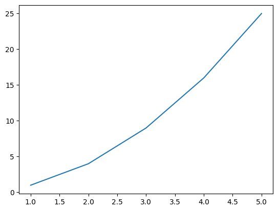

```python
plt.plot(X, Y)
```

## 4. Magic Commands

```python
%run ./hello.py
```

```python
dog_age?
```